# Branch-specific rate estimation (R2.2) and error vs trend (R2.3)

Supplementary analyses addressing Reviewer 2, comments R2.2 and R2.3.

- **R2.2**: Branch-specific rate estimation errors from the OBDD calibration study.
- **R2.3**: Estimation error as a function of the trend parameter.

Uses only the existing MCMC parameter traces from the calibration study (no re-simulation or posterior tree files needed).

# Load calibration data

```
Number of datasets: 500
```

# R2.2: Branch-specific rate estimation

In the OBDD model, branch-specific rates evolve according to a geometric Brownian motion parameterised by the root rates ($\lambda_0$, $\mu_0$), trend parameters ($\alpha_\lambda$, $\alpha_\mu$), and diffusion parameters ($\sigma_\lambda$, $\sigma_\mu$). These six parameters **fully determine** the distribution of branch-specific rates across the tree. If they are accurately recovered, the implied branch-rate distribution is accurately recovered.

## Recovery of GBM parameters

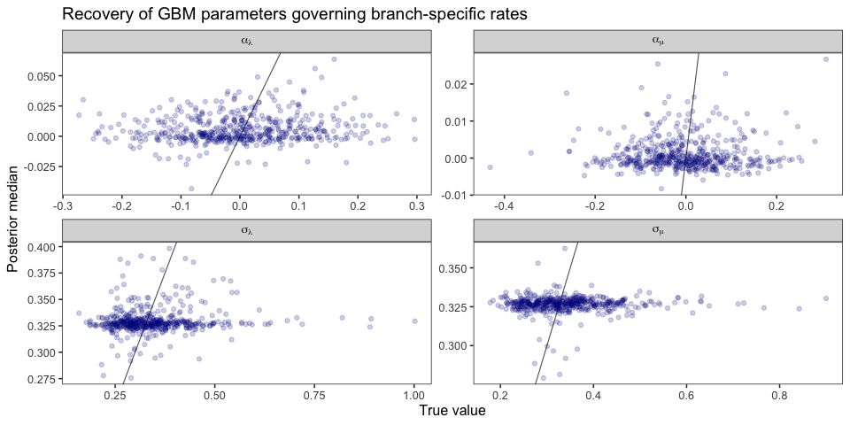

## Root rate recovery

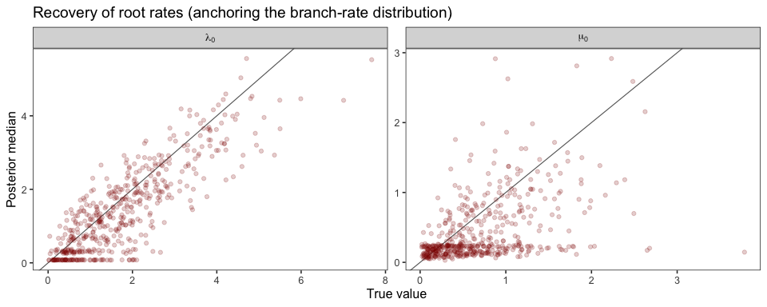

## Implied rate heterogeneity

Under the GBM, the variance of log-rates across branches at time $t$ from the root is $\sigma^2 t$. For a tree of height $h$, the expected standard deviation of log-$\lambda$ across lineages at the tips is approximately $\sigma_\lambda \sqrt{h}$. We can compare the implied heterogeneity from the true vs. posterior $\sigma$ estimates.

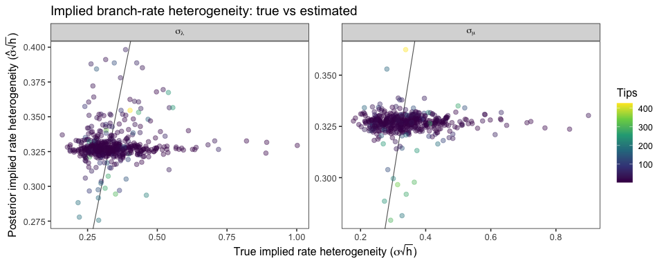

## NMSE of GBM parameters vs tree size

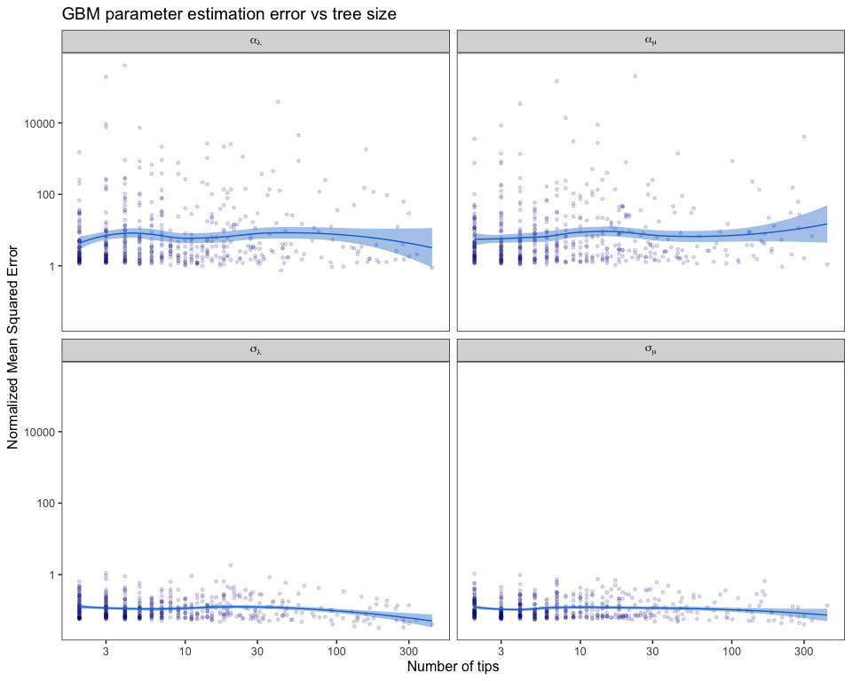

# R2.3: Estimation error vs trend parameter

The reviewer predicts that in models with a positive net-diversification trend ($\alpha_\lambda > 0$ or $\alpha_\mu < 0$), the estimation error should be smaller because the tree is expected to be larger and more informative.

## NMSE vs speciation trend $\alpha_\lambda$

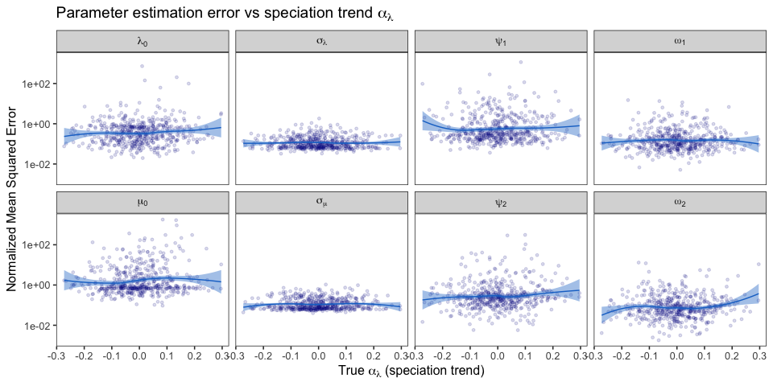

## NMSE vs net diversification trend $\alpha_\lambda - \alpha_\mu$

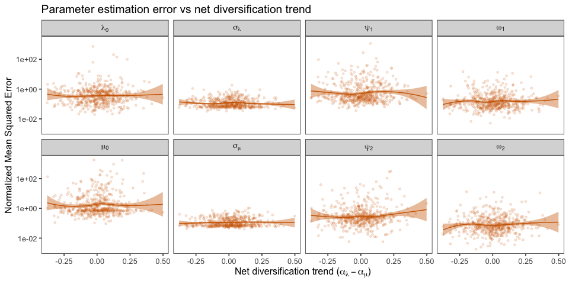

## NMSE vs extinction trend $\alpha_\mu$

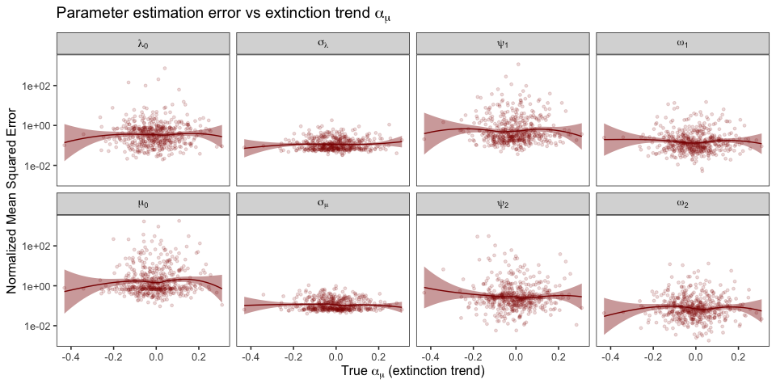

## Tree size as confound

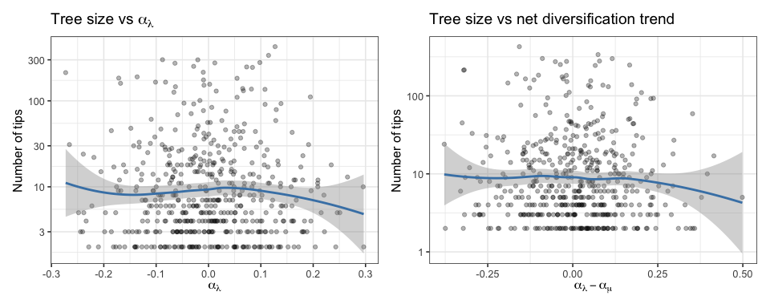